# Chapter 10 Exercises

Caitlyn Ralph

5/5/2018

# Conceptual Exercises

## 3. In this problem, you will perform K-means clustering manually, with K = 2, on a small example with n = 6 observations and p = 2 features. The observations are as follows.

```r
library(knitr)
obs<-c(1,2,3,4,5,6)
x1<-c(1,1,0,5,6,4)
x2<-c(4,3,4,1,2,0)
observations<-data.frame(obs,x1,x2)
colnames(observations)<- c("Obs","X1","X2")
kable(observations)
```

| Obs | X1 | X2 |
| --- | --- | --- |
| 1 | 1 | 4 |
| 2 | 1 | 3 |
| 3 | 0 | 4 |
| 4 | 5 | 1 |
| 5 | 6 | 2 |
| 6 | 4 | 0 |

### (a) Plot the observations.

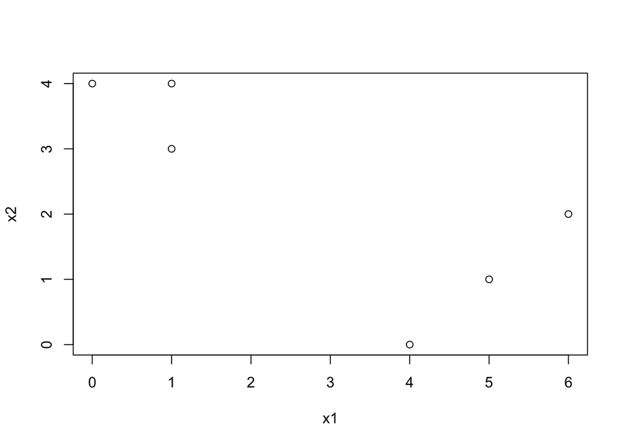

```r
plot(x1,x2)
```

### (b) Randomly assign a cluster label to each observation. You can use the sample() command in R to do this. Report the cluster labels for each observation.

```r
len <- dim(observations)[1]
label_1<-sample(len,len/2)
label_2<-(-label_1)

observations$Labels<-NA
observations$Labels[label_1]=1
observations$Labels[label_2]=2
```

### (c) Compute the centroid for each cluster.

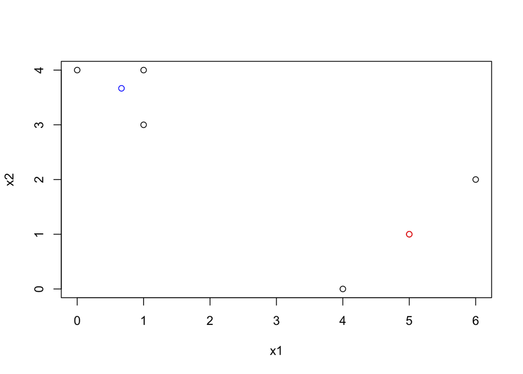

```r
c1_x1<-mean(observations$X1[label_1])
c1_x2<-mean(observations$X2[label_1])
c1<-c(c1_x1,c1_x2)

c2_x1<-mean(observations$X1[label_2])
c2_x2<-mean(observations$X2[label_2])
c2<-c(c2_x1,c2_x2)

plot(x1,x2)
points(c1_x1,c1_x2,col="blue")
points(c2_x1,c2_x2,col="red")
```

### (d) Assign each observation to the centroid to which it is closest, in terms of Euclidean distance. Report the cluster labels for each observation.

```r
observations$Labels_2<-NA

for (i in 1:len) {
  c1_dist<-sqrt((c1_x1-observations$X1[i])^2 + (c1_x2-observations$X2[i])^2)
  c2_dist<-sqrt((c2_x1-observations$X1[i])^2 + (c2_x2-observations$X2[i])^2)
  if (c1_dist < c2_dist) {
    observations$Labels_2[i]<-1
  } else {
    observations$Labels_2[i]<-2
  }
}
```

### (e) Repeat (c) and (d) until the answers obtained stop changing.

```r
c1_x1_3<-mean(observations$X1 == 1)
c1_x2_3<-mean(observations$X2 == 1)
c1_3<-c(c1_x1_3,c1_x2_3)

c2_x1_3<-mean(observations$X1 == 2)
c2_x2_3<-mean(observations$X2 == 2)
c2_3<-c(c2_x1_3,c2_x2_3)

observations$Labels_3<-NA

for (i in 1:len) {
  c1_dist<-sqrt((c1_x1_3-observations$X1[i])^2 + (c1_x2_3-observations$X2[i])^2)
  c2_dist<-sqrt((c2_x1_3-observations$X1[i])^2 + (c2_x2_3-observations$X2[i])^2)
  if (c1_dist < c2_dist) {
    observations$Labels_3[i]<-1
  } else {
    observations$Labels_3[i]<-2
  }
}

c1_x1_4<-mean(observations$X1 == 1)
c1_x2_4<-mean(observations$X2 == 1)
c1_4<-c(c1_x1_4,c1_x2_3)

c2_x1_4<-mean(observations$X1 == 2)
c2_x2_4<-mean(observations$X2 == 2)
c2_4<-c(c2_x1_4,c2_x2_4)

observations$Labels_4<-NA

for (i in 1:len) {
  c1_dist<-sqrt((c1_x1_4-observations$X1[i])^2 + (c1_x2_4-observations$X2[i])^2)
  c2_dist<-sqrt((c2_x1_4-observations$X1[i])^2 + (c2_x2_4-observations$X2[i])^2)
  if (c1_dist < c2_dist) {
    observations$Labels_4[i]<-1
  } else {
    observations$Labels_4[i]<-2
  }
}
```

### (f) In your plot from (a), color the observations according to the cluster labels obtained.

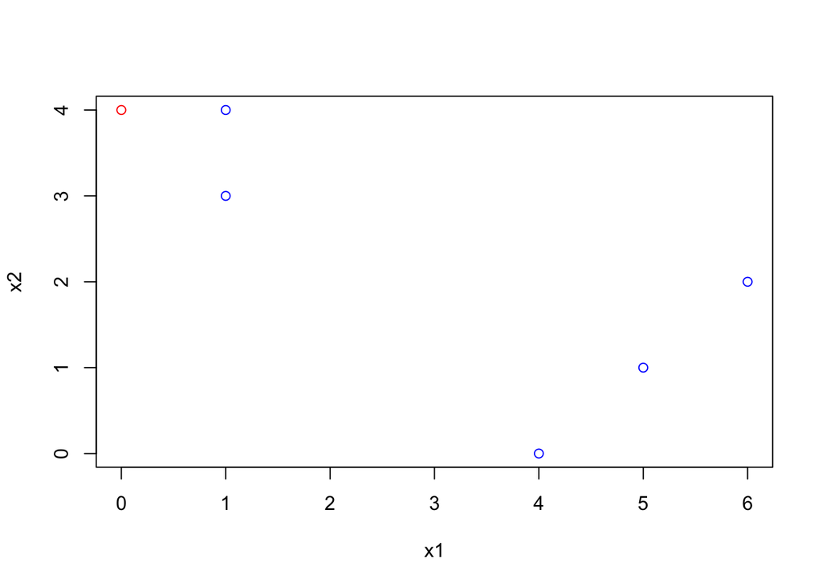

```r
plot(x1,x2,col=ifelse(observations$Labels_4 == 1,'blue','red'))
```

# Applied Exercises

## 9. Consider the USArrests data. We will now perform hierarchical clustering on the states.

### (a) Using hierarchical clustering with complete linkage and Euclidean distance, cluster the states.

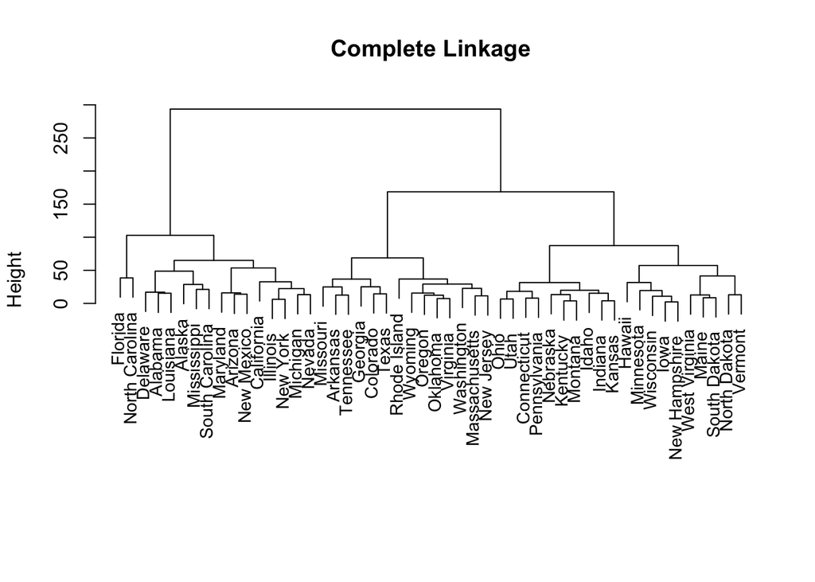

```r
hc.complete<-hclust(dist(USArrests),method="complete")
plot(hc.complete,main="Complete Linkage",xlab="",sub="",cex=.9)
```

### (b) Cut the dendrogram at a height that results in three distinct clusters. Which states belong to which clusters?

```r
cutree(hc.complete,3)
```

```
##        Alabama         Alaska        Arizona       Arkansas     California
##              1              1              1              2              1
##       Colorado    Connecticut       Delaware        Florida        Georgia
##              2              3              1              1              2
##         Hawaii          Idaho       Illinois        Indiana           Iowa
##              3              3              1              3              3
##         Kansas       Kentucky      Louisiana          Maine       Maryland
##              3              3              1              3              1
##  Massachusetts       Michigan      Minnesota    Mississippi       Missouri
##              2              1              3              1              2
##        Montana       Nebraska         Nevada  New Hampshire     New Jersey
##              3              3              1              3              2
##     New Mexico       New York North Carolina   North Dakota           Ohio
##              1              1              1              3              3
##       Oklahoma         Oregon   Pennsylvania   Rhode Island South Carolina
##              2              2              3              2              1
##   South Dakota      Tennessee          Texas           Utah        Vermont
##              3              2              2              3              3
##       Virginia     Washington  West Virginia      Wisconsin        Wyoming
##              2              2              3              3              2
```

### (c) Hierarchically cluster the states using complete linkage and Euclidean distance, after scaling the variables to have standard deviation one.

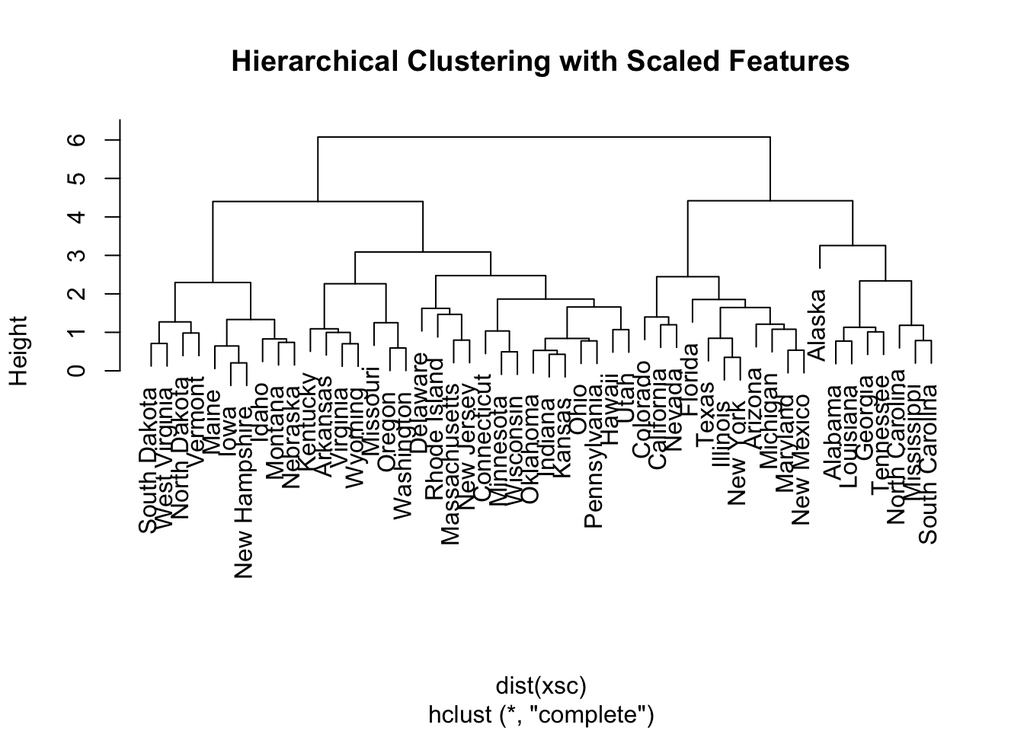

```r
xsc=scale(USArrests)
plot(hclust(dist(xsc),method="complete"),main="Hierarchical Clustering with Scaled Features")
```

```r
cutree(hc.complete,3)
```

```
##        Alabama         Alaska        Arizona       Arkansas     California
##              1              1              1              2              1
##       Colorado    Connecticut       Delaware        Florida        Georgia
##              2              3              1              1              2
##         Hawaii          Idaho       Illinois        Indiana           Iowa
##              3              3              1              3              3
##         Kansas       Kentucky      Louisiana          Maine       Maryland
##              3              3              1              3              1
##  Massachusetts       Michigan      Minnesota    Mississippi       Missouri
##              2              1              3              1              2
##        Montana       Nebraska         Nevada  New Hampshire     New Jersey
##              3              3              1              3              2
##     New Mexico       New York North Carolina   North Dakota           Ohio
##              1              1              1              3              3
##       Oklahoma         Oregon   Pennsylvania   Rhode Island South Carolina
##              2              2              3              2              1
##   South Dakota      Tennessee          Texas           Utah        Vermont
##              3              2              2              3              3
##       Virginia     Washington  West Virginia      Wisconsin        Wyoming
##              2              2              3              3              2
```